# Digital Biomarker Discovery for Eye Disorders using EEG Data

Prepared by Kui Hong Lim  
Email: kuihong.lim@students.fhwn.ch  
Github  
Module : Digital Biomarker  
Master of Informatics  
University of Applied Sciences and Arts Northwestern Switzerland

## Objective

The objective of this project is to develop a digital biomarker using EEG data that can accurately identify individuals with eye disorders characterized by the need for long and stronger blinks. Students will analyze EEG signals obtained from four electrodes to find a biomarker that can be used to diagnose this eye disorder efficiently.

## Project Tasks

| Index | Task |
| --- | --- |
| 1 | Data download and Preprocessing |
| 2 | Feature Extraction |
| 3 | Biomarker Selection and Visualization |
| 4 | Model Development, Validation and Evaluation |

**1. Data download and preprocessing**

1.1 Data cleaning and understanding

1.2 Load data, and parsing it from string to appropriate data type.

1.3 Scaling the value

The objective here is to standardize the magnitude of the variations in the raw signale from the four electrodes into a consistent range between 20 and 100 μV. Standardizing the range helps to achieve consistent and comparable magnitudes across the electrodes. Additionally, scaled data of similar amplitudes can lead to better convergence and efficient training for machine learning. In order to rescale the raw signal values to the desired range between 20 and 100 μV, min-max scaling is applied.

1.4 Apply PSD (power spectral density) to observe the distribution of power across different frequencies in the EEG signal.

```python
import numpy as np
import scipy as sp
import pandas as pd
import matplotlib.pyplot as plt
from scipy import signal
from scipy.signal import lfilter

%matplotlib inline
```

```python
# Long blink data
#df1 = pd.read_csv('/LongBlink_test.csv', sep = ",") -#google colab
df1 = pd.read_csv('data\\LongBlink_test.csv', sep = ",")
df1[['Col1', 'Col2', 'Col3', 'Col4']] = df1['data'].str.split(',', expand=True)
# Remove the original 'HeaderColumn' column
df1.drop(columns=['data'], inplace=True)
df1.head(5)
ser1 = df1.iloc[:,0].str.strip('[').astype(float) #to remove square brackets and convert to float
ser2 = df1.iloc[:,1].astype(float) #convert to float
ser3 = df1.iloc[:,2].astype(float) #convert to float
ser4 = df1.iloc[:,3].str.strip(']').astype(float) #remove square brackets and convert to float
# ser 1,2,3,4 are numpy arrays, length: 25500, dtype: float64
df1 = pd.concat([ser1, ser2, ser3, ser4], axis=1)
df1.columns = ['ser1', 'ser2', 'ser3', 'ser4']
```

```python
#!pip install mne #google colab
import mne
from sklearn.preprocessing import MinMaxScaler

n_channels = len(df1.columns) #define number of channels
#print(n_channels)
ch_names = list(df1) #list of channel names

#Min-max scaling
scaler = MinMaxScaler(feature_range=(0.000020,0.000100)) #scale the data to the range of 20 to 100 uV
df_scaled = scaler.fit_transform(df1.to_numpy())
df1_norm = pd.DataFrame(df_scaled, columns=df1.columns)
#print(df1_norm.head(5))
values = df1_norm.T # transpose the dataframe
#print(values)
ch_types = ['eeg']*df1.shape[1]
sampling_freq = 215

info = mne.create_info(ch_names=ch_names, sfreq=sampling_freq, ch_types=ch_types)
raw_lb = mne.io.RawArray(values, info)
raw_lb.save('.\\data\\raw_lb.fif', overwrite=True)
raw_lb.compute_psd().plot(average=True, picks="data", exclude="bads").show()
```

[output not shown]

```python
# Get pandas dataframe from raw format
lb_data = raw_lb.to_data_frame()
lb_data = lb_data.drop("time", axis=1) #drop "time" column

# Get pandas series to use in data preprocessing
ser1 = lb_data["ser1"]
ser2 = lb_data["ser2"]
ser3 = lb_data["ser3"]
ser4 = lb_data["ser4"]
lb_data
```

**1. Data download and processing**

1.4 Filtering EEG data Apply the following filter function:

butterworth bandpass filter function : select moderate level of filtering 4th order, frequencies below 20 Hz will be allowed to pass through while higher frequencies will be attenuated

finite impulse filter: taken from https://www.daanmichiels.com/blog/2017/10/filtering-eeg-signals-using-scipy/

**Reference**

- [Electroencephalograph](https://en.wikipedia.org/wiki/Electroencephalography#:~:text=A%20healthy%20human%20EEG%20will,between%2020%20and%20100%20%CE%BCV)
- [Origin, significance, and interpretation of EEG](https://www.youtube.com/watch?v=Bmt89hHyxuM)

**Reference code**

- [Professor Reto Wildhaber's exercises and notes]
- [Tutorial MNE RAW EEG CSV](https://colab.research.google.com/drive/1ro2XBhpUKIlV5JCytetKoNFrVOCgdLAP?usp=sharingLink#scrollTo=T4VzMOJKSXlz)
- [Overview of artifact detection](https://mne.tools/dev/auto_tutorials/preprocessing/10_preprocessing_overview.html)
- (EEG Data Processing)(https://neuro.inf.unibe.ch/AlgorithmsNeuroscience/Tutorial_files/introToSP.html)
- [Filtering EEG Data](https://neuraldatascience.io/7-eeg/erp_filtering.html) -[EEG Signal Processing for Dummies](https://www.neuroelectrics.com/blog/2014/12/18/eeg-signal-processing-for-dummies/)
- [EEG_signal_processing](https://www.kaggle.com/code/sam1o1/eeg-signal-processing)
- [Filtering EEG signals using SciPy](https://www.daanmichiels.com/blog/2017/10/filtering-eeg-signals-using-scipy/)

```python
# Define the slice to display in the following code. Just change the value of 'SLICE_FROM' with 0 or a multiple of 510
SLICE_FROM = 510
SLICE_TO = SLICE_FROM + 510

# Create moving average filter function, Prof. Wildhaber exercise
def moving_average_filter(data: np.ndarray, L: int) -> np.ndarray:
    h = np.ones(L)/L
    y = lfilter(h, [1], data)
    y_ = np.roll(y, shift= -int(L/2))
    return y_

# Create a butterworth bandpass filter function, Prof. Wildhaber exercise
# source: https://scipy-cookbook.readthedocs.io/items/ButterworthBandpass.html
def butter_bandpass(lowcut, highcut, fs, order=4) -> tuple:
    nyq = 0.5 * fs
    low = lowcut / nyq
    high = highcut / nyq
    b, a = signal.butter(order, [low, high], btype='band')
    return b, a

def butter_bandpass_filter(data: pd.Series, lowcut: float, highcut: float, fs: float, order=4) -> np.ndarray:
    b, a = butter_bandpass(lowcut, highcut, fs, order=order)
    y = signal.lfilter(b, a, data)
    return y
```

```python
# Create a processing function

def processing(data: pd.DataFrame, slice_from: int, slice_to: int) -> pd.DataFrame:
    # Define moving average filter parameters
    L = 3

    # Define butter bandpass filter parameters
    lowpass = 20
    highpass = None # Nyquist frequency is half of the sampling rate of 215 Hz
    fs = 215
    order = 4

    # Create an empty pandas DataFrame
    cleaned_data = pd.DataFrame()

    # Loop through all columns and apply the filters
    for key, value in data.items():

        # converting the data to numpy series
        series_raw = value.to_numpy()

        # for each column plot all the filters results
        fig, ax0 = plt.subplots(1, 1, figsize=(15,5)) # 4 rows, 1 column


        # apply moving_average_filter
        series_maf = moving_average_filter(series_raw, L)

        # apply butter bandpass filter
        b, a = signal.iirfilter(order, [lowpass,], fs=fs, ftype='butter', btype='lowpass')
        series_bbf = signal.filtfilt(b, a, series_maf)

        # apply FIR filter
        cutoff_freq = [0.01, 0.06] #Hz
        firwin_filter = signal.firwin(430, cutoff_freq, pass_zero=False)
        series_firwin = signal.convolve(value, firwin_filter, mode='same')

        cleaned_data[key] = series_firwin

        # plot each steps ax0 raw value, ax1 after butter bandpass, ax2 after median, ax3 after notch filter.
        ax0.set_title('Data')
        ax0.set_xlabel('Data Point')
        ax0.set_ylabel('Amplitude (\u03BCV)')

        plot_row, = ax0.plot(series_raw[slice_from:slice_to], color="grey", label='raw data')

        plot_ma, = ax0.plot(series_maf[slice_from:slice_to], color="blue", linewidth='2', label='moving average')

        plot_butter, = ax0.plot(series_bbf[slice_from:slice_to], color="red", label='butter')

        plot_firwin, = ax0.plot(series_firwin[slice_from:slice_to], color="orange", label='firwin')

        ax0.legend(handles=[plot_row, plot_ma, plot_butter, plot_firwin])


        fig.suptitle(f"Filters apply to '{key}'")

    return cleaned_data
```

```
(25500, 4)
```

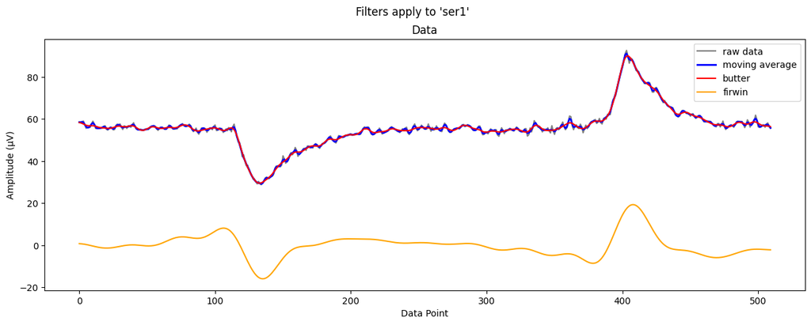

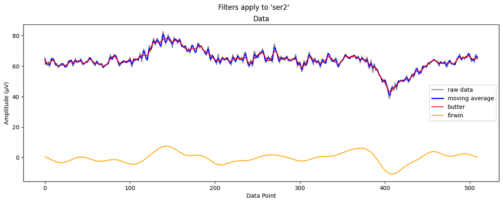

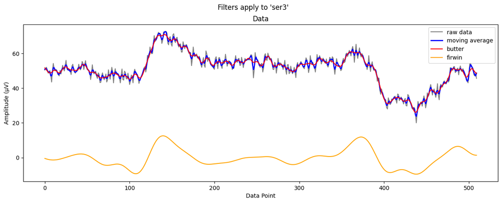

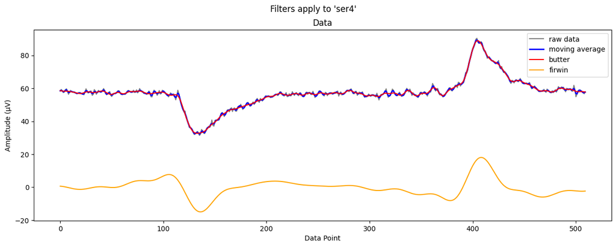

```python
lb_cleaned = processing(lb_data, SLICE_FROM, SLICE_TO)
print(lb_cleaned.shape)
```

**1. Data download and processing**

1.5 Data preprocessing and filtering on short blink data

The same steps to process and filter long blink data are applied on the short blink data.

```python
# Short blink data
df2 = pd.read_csv('data\\ShortBlink_test.csv', sep = ",")
df2[['Col1', 'Col2', 'Col3', 'Col4']] = df2['data'].str.split(',', expand=True)
# Remove the original 'HeaderColumn' column
df2.drop(columns=['data'], inplace=True)
df2.head(5)
ser1 = df2.iloc[:,0].str.strip('[').astype(float) #to remove square brackets and convert to float
ser2 = df2.iloc[:,1].astype(float) #convert to float
ser3 = df2.iloc[:,2].astype(float) #convert to float
ser4 = df2.iloc[:,3].str.strip(']').astype(float) #remove square brackets and convert to float
# ser 1,2,3,4 are numpy arrays, length: 25500, dtype: float64
df2 = pd.concat([ser1, ser2, ser3, ser4], axis=1) #concatenate the columns
df2.columns = ['ser1', 'ser2', 'ser3', 'ser4'] #rename the columns
```

```python
#Min-max scaling
scaler = MinMaxScaler(feature_range=(0.000020,0.000100)) #scale the data to the range of 20 to 100 uV
df_scaled = scaler.fit_transform(df2.to_numpy())
df2_norm = pd.DataFrame(df_scaled, columns=df2.columns)
#print(df1_norm.head(5))
values = df2_norm.T # transpose the dataframe
#print(values)
ch_types = ['eeg']*df2.shape[1]
sampling_freq = 215

info = mne.create_info(ch_names=ch_names, sfreq=sampling_freq, ch_types=ch_types)
raw_sb = mne.io.RawArray(values, info)
raw_sb.save('.\\data\\raw_sb.fif', overwrite=True)
raw_sb.compute_psd().plot(average=True, picks="data", exclude="bads").show()
```

[output not shown]

```python
# Get pandas dataframe from raw format
sb_data = raw_sb.to_data_frame()
#print(lb_data)
sb_data = sb_data.drop("time", axis=1) #drop "time" column

# Get pandas series to use in data preprocessing
ser1 = sb_data["ser1"]
ser2 = sb_data["ser2"]
ser3 = sb_data["ser3"]
ser4 = sb_data["ser4"]
#print(type(ser1))
sb_data
```

```
(25500, 4)
```

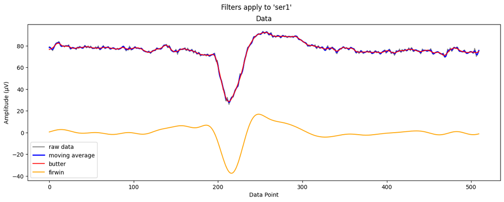

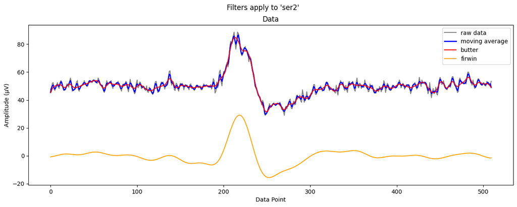

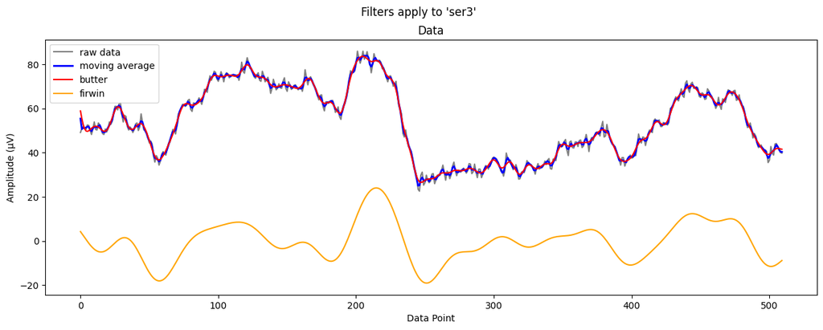

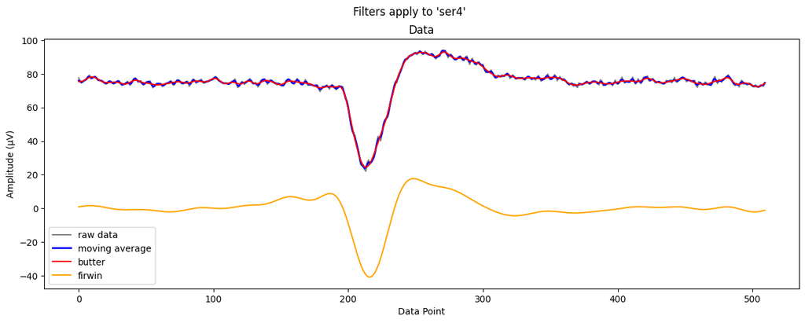

```python
sb_cleaned = processing(sb_data, SLICE_FROM, SLICE_TO)
print(sb_cleaned.shape)
```

**2. Feature Extraction**

2.1 Binarization

Subsequently, statistical feature extraction is employed to identify important signal attributes such as amplitude variation. These features offer valuable insights into the signal and contribute to the system's accuracy. The statistical features used are:

1. Energy

Energy is calculated to find the spreading out of the data values around the mean.Energy provides information about the intensity or power of the signal. Peaks in energy may correspond to periods of increased neural activity or certain events captured by the EEG.

2. Kurtosis

In a probability distribution, it measures the outliers present.

3. Skewness

Skewness describes asymmetry from the normal distribution in a set of statistical data, as data becomes more symmetrical as its value approaches zero. Normally distributed data, by definition has little skewness and on other hand positively skewed or right sided skewed data has positive and negatively skewed or left sided skewed has negative value.

[output not shown]

It is observed that energy, kurtosis, and skewness show some good variation between the two classes. Therefore, these parameters are considered for analysis.

**Reference**

- [Selection of Appropriate Statistical Features of EEG Signals for Detection of Parkinson’s Disease](https://ieeexplore.ieee.org/document/9200194/authors#authors)
- [Detection of Epileptic Seizure in EEG Recordings by Spectral Method and Statistical Analysis](https://scialert.net/fulltext/?doi=jas.2013.207.219)

**Source code**

- [EEG Features](https://github.com/vancleys/EEGFeatures/blob/master/TimeDomain/Mean.py)
- [EEG ML Classification](https://github.com/talhaanwarch/youtube-tutorials/blob/main/2.1%20EEG%20ML%20classification.ipynb)
- [Annotation](https://matplotlib.org/2.0.2/users/annotations.html#:~:text=pad%3D0.6%22)

```python
lb_cleaned.shape
sb_cleaned.shape
```

```
(25500, 4)
```

```python
# number of batch per sequence
25500/510
```

```
50.0
```

```python
# Create a function to split data into batches
def get_transposed_numpy_batched_array(array: np.array, batch_size: int):
    l = []
    for i in range(batch_size, len(array)+batch_size, batch_size):
        l.append(array[i-batch_size:i].T.to_numpy())
    # print(array[i-batch_size:i].T)
    return np.array(l)

# Create an array of long blink epochs and class labels
long_blink_epochs_array = get_transposed_numpy_batched_array(lb_cleaned, 510)
long_blink_labels = len(long_blink_epochs_array)*[1]

# Create an array of short blink epochs and class labels
short_blink_epochs_array = get_transposed_numpy_batched_array(sb_cleaned, 510)
short_blink_labels = len(short_blink_epochs_array)*[0]

# Concatenate the long and short blink epochs and class labels to create the final dataset for training
blink_epochs_array = np.concatenate([long_blink_epochs_array, short_blink_epochs_array])
blink_labels = np.concatenate([long_blink_labels, short_blink_labels])


blink_epochs_array.shape, blink_labels.shape
```

```
((100, 4, 510), (100,))
```

```python
blink_epochs_array.shape
```

```
(100, 4, 510)
```

```python
pd.DataFrame(blink_epochs_array[0])
```

|  | 0 | 1 | 2 | 3 | 4 | 5 | 6 | 7 | 8 | 9 | ... | 500 | 501 | 502 | 503 | 504 | 505 | 506 | 507 | 508 | 509 |
| --- | --- | --- | --- | --- | --- | --- | --- | --- | --- | --- | --- | --- | --- | --- | --- | --- | --- | --- | --- | --- | --- |
| 0 | -1.095594 | 1.734547 | 4.539968 | 7.281797 | 9.922515 | 12.426768 | 14.762139 | 16.899758 | 18.814881 | 20.487496 | ... | 0.411046 | 0.496900 | 0.578563 | 0.653479 | 0.719241 | 0.773601 | 0.814460 | 0.839953 | 0.848520 | 0.839137 |
| 1 | -0.056264 | 3.229472 | 6.475748 | 9.637965 | 12.673420 | 15.542214 | 18.208042 | 20.638729 | 22.807021 | 24.691141 | ... | 2.038416 | 1.977596 | 1.899477 | 1.802948 | 1.687051 | 1.551265 | 1.395575 | 1.220207 | 1.025556 | 0.812521 |
| 2 | 0.513087 | 3.102987 | 5.655919 | 8.135236 | 10.505876 | 12.735181 | 14.793401 | 16.654437 | 18.296298 | 19.701559 | ... | 1.255635 | 1.109438 | 0.949625 | 0.778681 | 0.599176 | 0.413797 | 0.225333 | 0.036843 | -0.148883 | -0.329292 |
| 3 | -0.575128 | 2.343374 | 5.226025 | 8.032320 | 10.723351 | 13.262663 | 15.617052 | 17.757346 | 19.658884 | 21.302042 | ... | 0.239899 | 0.336664 | 0.426271 | 0.506147 | 0.574093 | 0.628014 | 0.666023 | 0.686581 | 0.688501 | 0.671161 |

4 rows × 510 columns

```python
# Create a group list for the blink epochs as part of EEG ML classification model
groups_list=[i for i, _ in enumerate(blink_epochs_array)]
```

```python
from scipy import stats

def energy(data, axis=None):
    return np.sum(np.square(data), axis=axis)

def kurtosis(data, axis=None):
    return stats.kurtosis(data,axis=axis)

def skewness(data, axis=None):
     return stats.skew(data, axis=axis)

def concatenate_features(data, axis=None):
    return np.concatenate((energy(data, axis=axis), kurtosis(data, axis=axis), skewness(data, axis=axis)), axis=axis)
```

```python
# Calculate statistical features for each column

lb_energy_values = energy(long_blink_epochs_array)
lb_kurtosis_values = kurtosis(long_blink_epochs_array)
lb_skew_values = skewness(long_blink_epochs_array)

print("{:e}".format(lb_energy_values))
print("{:e}".format(lb_kurtosis_values))
print("{:e}".format(lb_skew_values))


sb_energy_values = energy(short_blink_epochs_array)
sb_kurtosis_values = kurtosis(short_blink_epochs_array)
sb_skew_values = skewness(short_blink_epochs_array)


print("{:e}".format(sb_energy_values))
print("{:e}".format(sb_kurtosis_values))
print("{:e}".format(sb_skew_values))


# Create a list of statistical feature names
feature_names = ["Energy", "Kurtosis", "Skewness"]

# Create a list of statistical feature values for each column
lb_feature_values = [lb_energy_values, lb_kurtosis_values, lb_skew_values]
sb_feature_values = [sb_energy_values, sb_kurtosis_values, sb_skew_values]

l = [i for i in range(len(feature_names))]
```

```
3.101146e+06
3.244961e+00
-7.588133e-02
4.242203e+06
9.472968e+00
-5.965848e-01
```

```python
# 100 rows of 16 features, 4 features for each of the 4 channels
features_list=[]
for data in blink_epochs_array:
    features_list.append(concatenate_features(data, axis=-1))
features=np.array(features_list)
features.shape
```

```
(100, 12)
```

**3. Biomarker Selection and Visualization**

In the context of biomarker selection, the random forest algorithm, which employs multiple decision tree classifiers on various subsets of the dataset is applied. Averaging is used to enhance predictive accuracy and control overfitting.

**Reference**

- [Feature Selection with Random Forest](https://www.yourdatateacher.com/2021/10/11/feature-selection-with-random-forest/)
- [Understanding Random Forest Better through Visualization](https://garg-mohit851.medium.com/random-forest-visualization-3f76cdf6456f)

**Reference Code**

- [stackoverflow](https://stackoverflow.com/questions/6146290/plotting-a-line-over-several-graphs)

```python
from sklearn.ensemble import RandomForestClassifier
from sklearn.feature_selection import SelectFromModel
from sklearn.model_selection import train_test_split
from sklearn.model_selection import cross_val_score

X_train, X_test, y_train, y_test = train_test_split(features, blink_labels, test_size=0.25, random_state=42, shuffle=True)

for n_trees in [50, 100, 200, 500]:
    # Create RandomForestClassifier with current n_estimators
    forest = RandomForestClassifier(n_estimators=n_trees, random_state=42)

    # Use cross_val_score for evaluation
    scores = cross_val_score(forest, X_train, y_train, cv=5)  # 5-fold cross-validation
    mean_score = scores.mean()

    print(f"n_estimators={n_trees}, Mean Cross-Validation Score: {mean_score}")
```

```
n_estimators=50, Mean Cross-Validation Score: 0.9866666666666667
n_estimators=100, Mean Cross-Validation Score: 0.9866666666666667
n_estimators=200, Mean Cross-Validation Score: 0.9733333333333334
n_estimators=500, Mean Cross-Validation Score: 0.9733333333333334
```

```python
# Create and train a random forest (code is learned from kaggle on other dataset irrelavant to this project)
forest= RandomForestClassifier(n_estimators= 50, random_state= 42)
forest.fit(X_train, y_train)

# Get the most important features
forest_feats= SelectFromModel(forest, threshold= 'median')
forest_feats.fit(X_train, y_train)

# Get training and development sets that have only the most important features
X_train_forest= forest_feats.transform(X_train)
X_devel_forest= forest_feats.transform(X_test)

# Features that will be retained
for i in forest_feats.get_support(indices= True):
    print(X_train[i])
```

[output not shown]

```python
# generating rows name for plot
columns_plot = []
for i in feature_names:
    for j in range(4):
        columns_plot.append(f"ser{j+1}_{i.lower()}")
columns_plot.append("output\n0=short blink\n1=long blink")
columns_plot
```

```python
df3 = pd.DataFrame(np.concatenate((X_train, y_train[:, None]), axis=1), columns=columns_plot ) #y_train[:, None] only take the first column
df3.head(5), df3.shape
```

```python
# color list for the next plot
import matplotlib.colors as mcolors
colors = 2*[ color.split(':')[1] for color in mcolors.TABLEAU_COLORS ]
colors
```

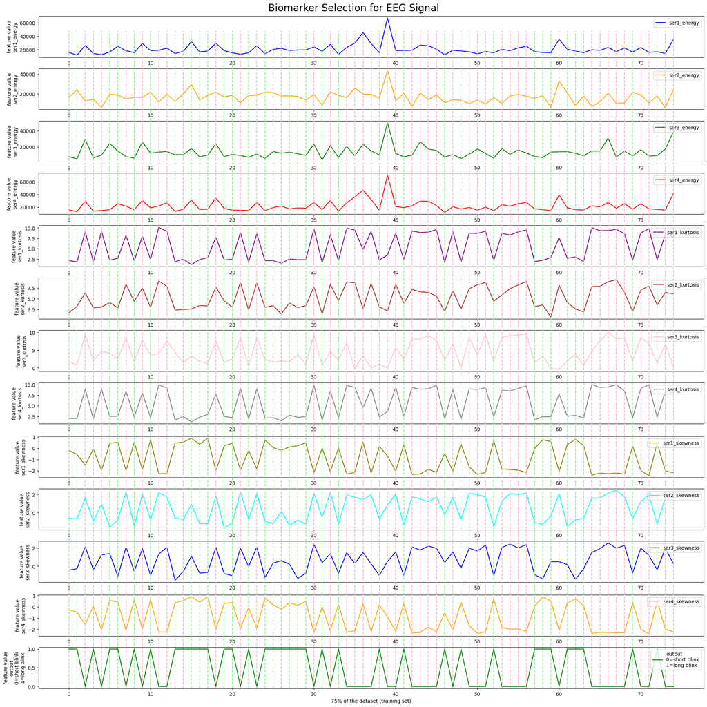

```python
import matplotlib as mpl

df4 = df3.T

mpl.rcParams['figure.constrained_layout.use'] = True

fig, axs = plt.subplots(nrows=df4.shape[0], figsize=(20, 20))

for i in range(df4.shape[0]):
    axs[i].plot(df4.iloc[i], label=str(df4.index[i]), color=colors[i])
    axs[i].legend(loc='upper right')
    axs[i].set_ylabel(f"feature value\n{str(df4.index[i])}")

for i in range(len(df3)):
    if df3.iloc[i,-1:].values == 1:
        # if 1 == long blink and print lightgreen line
        plt.axvline(x=i, ymin=0, ymax=16, color='lightgreen', linestyle='--',zorder=0, clip_on=False)
    else:
        # if 0 == short blink and print lightpink line
        plt.axvline(x=i, ymin=0, ymax=16, color='lightpink', linestyle='--',zorder=0, clip_on=False)

fig.suptitle('Biomarker Selection for EEG Signal', fontsize=20)
plt.xlabel('75% of the dataset (training set)')

plt.show()
```

```python
X_train_forest.shape, y_train.shape
```

**4. Model and Evaluation**

The dataset is processed using the classical machine learning model, Support Vector Classifier (SVC), yielding amazing results:

[output not shown]

##### Classification report: SVC

| Class | Precision | Recall | F1-score |
| --- | --- | --- | --- |
| 0 | 1.00 | 1.00 | 1.00 |
| 1 | 1.00 | 1.00 | 1.00 |

**Reference**

- [InterpretationHow to Interpret the Classification Report in sklearn (With Example)](https://www.statology.org/sklearn-classification-report/)

**Reference Code**

- [Applying Machine Learning Methods](https://github.com/aath0/AlgorithmsNeuroscience/blob/master/Tutorials/ApplyingMachineLearningMethods_1.ipynb)
- [The Sequential Model](https://keras.io/guides/sequential_model/)

```python
from sklearn.svm import SVC

svc = SVC()
_ = svc.fit(X_train_forest, y_train)

train_score_c4 = svc.score(X_train_forest, y_train)
test_score_c4 = svc.score(X_devel_forest, y_test)

print(f"Classical SVC on the training dataset: {train_score_c4:.2f}")
print(f"Classical SVC on the test dataset:     {test_score_c4:.2f}")
```

```
Classical SVC on the training dataset: 0.99
Classical SVC on the test dataset:     1.00
```

```python
from sklearn.metrics import classification_report
y_pred = svc.predict(X_devel_forest)
classification_report(y_test, y_pred)
print(classification_report(y_test, y_pred))
```

```
              precision    recall  f1-score   support

           0       1.00      1.00      1.00        11
           1       1.00      1.00      1.00        14

    accuracy                           1.00        25
   macro avg       1.00      1.00      1.00        25
weighted avg       1.00      1.00      1.00        25
```

**5. Conclusion**

In conclusion, this project aimed to develop a digital biomarker using EEG data for the accurate identification of individuals with eye disorders characterized by distinct blink patterns. The initial phase involved comprehensive data preprocessing, including data cleaning, formatting, scaling, and artifact detection. To standardize the magnitude of EEG signal variations, min-max scaling was applied, ensuring a consistent range between 20 and 100 μV across the four electrodes. Subsequent filtering steps were implemented to enhance data quality and interpretability.

Feature extraction focused on statistical measures such as energy, kurtosis, and skewness. Random Forest, a robust algorithm for biomarker selection, was employed to identify important features. Visualization of the selected biomarkers revealed distinctive patterns between long and short blinks, particularly in the Kurtosis feature.

The model development phase utilized support vector classifier (SVC). Evaluation metrics such as precision, recall, and F1-score were employed to assess model performance. The Support Vector Classifier has demonstrated superior performance.

This project provides a comprehensive framework for leveraging EEG data as a potential biomarker for eye disorders.